# Assignment 6: Visualization - Aesthetic Mapping

*How to do it?*:

- Open the Rmarkdown file of this assignment (link) in Rstudio.
- Right under each **question**, insert a code chunk (you can use the hotkey `Ctrl + Alt + I` to add a code chunk) and code the solution for the question.
- `Knit` the rmarkdown file (hotkey: `Ctrl + Alt + K`) to export an html.
- Publish the html file to your Githiub Page.

*Submission*: Submit the link on Github of the assignment to Canvas.

### Questions on Your Selected Data

Choose a dataset and produce the following types of plots and comment on each plot. Plots should be meaningful. If you use the data we used in class, make sure the plots are not the same as the ones in the slides.

1. For one continuous variable:
- Density
- Histogram
- Boxplot

```r
library(tidyverse)
library(knitr)
df <- read_csv('https://raw.githubusercontent.com/nytimes/covid-19-data/master/us-states.csv')
```

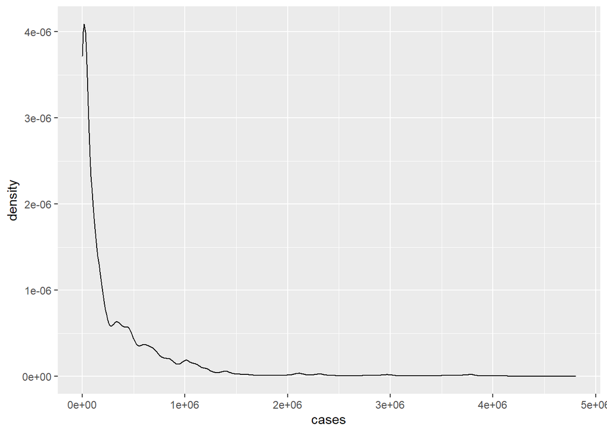

```r
df %>% ggplot()+
  geom_density(mapping = aes(x = cases))
```

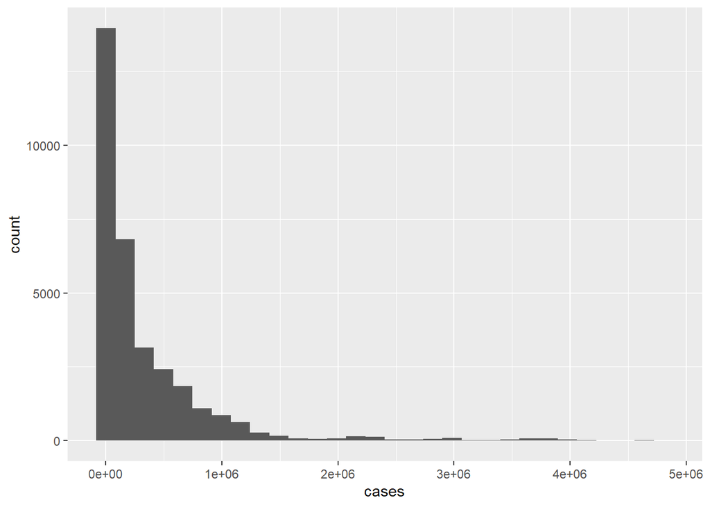

```r
df %>% ggplot()+
  geom_histogram(mapping = aes(x = cases))
```

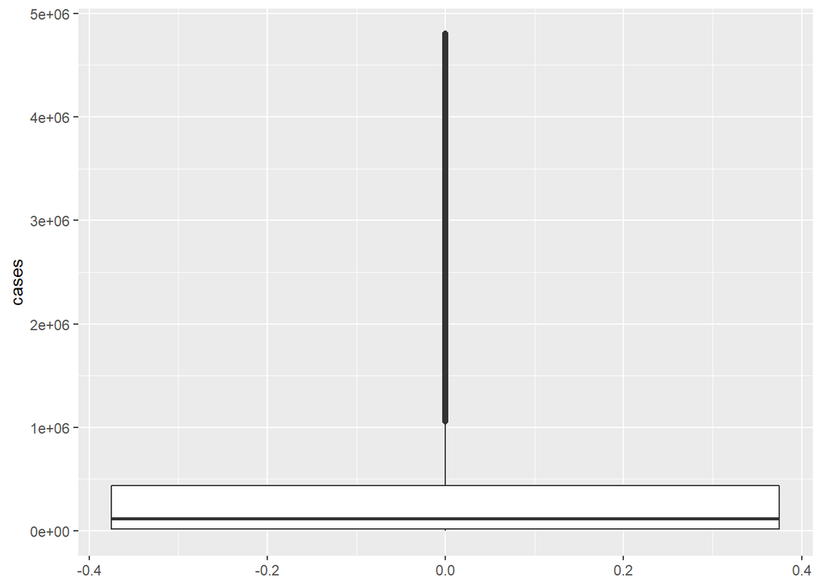

```r
df %>% ggplot()+
  geom_boxplot(mapping = aes(y = cases))
```

2. For one categorical variable
- Barplot

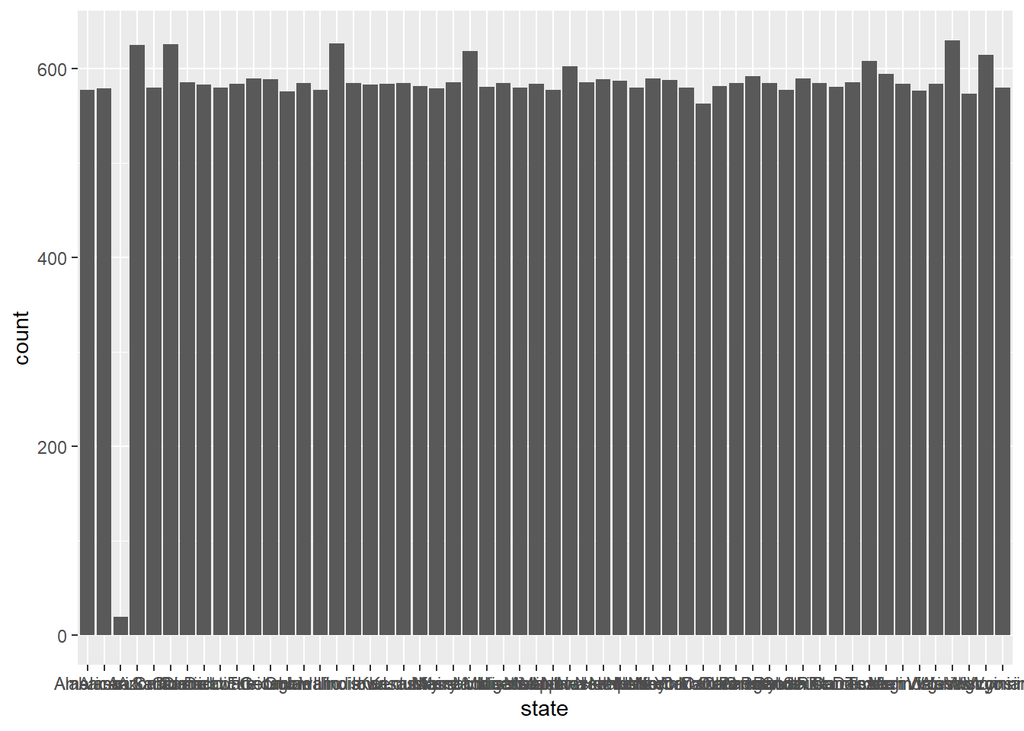

```r
df %>% ggplot()+
  geom_bar(mapping = aes(x = state))
```

3. For one two continuous variables
- Scatter Plot

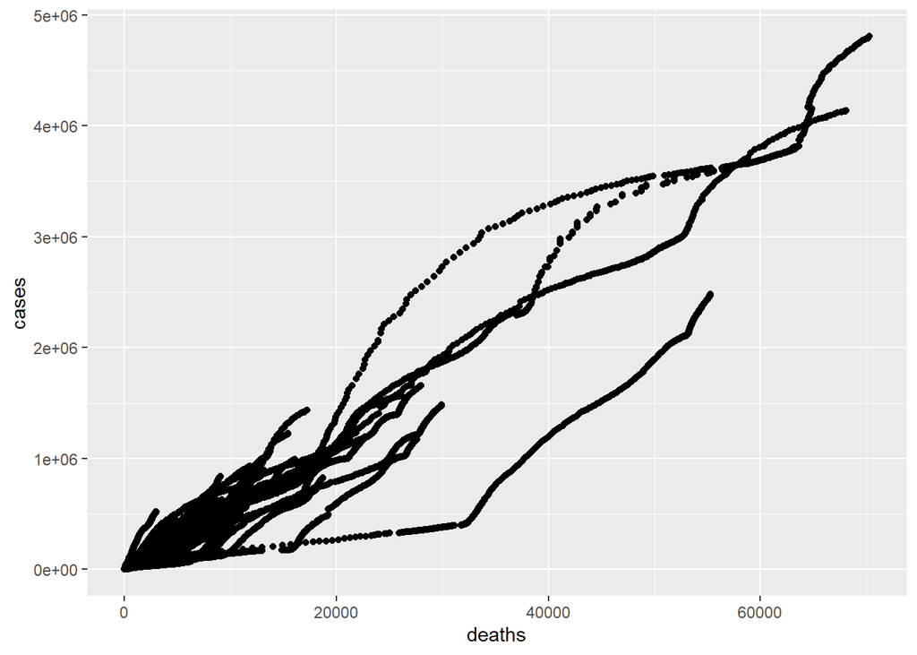

```r
df %>% ggplot()+
  geom_point(mapping = aes(x = deaths, y = cases))
```

- Line Plot

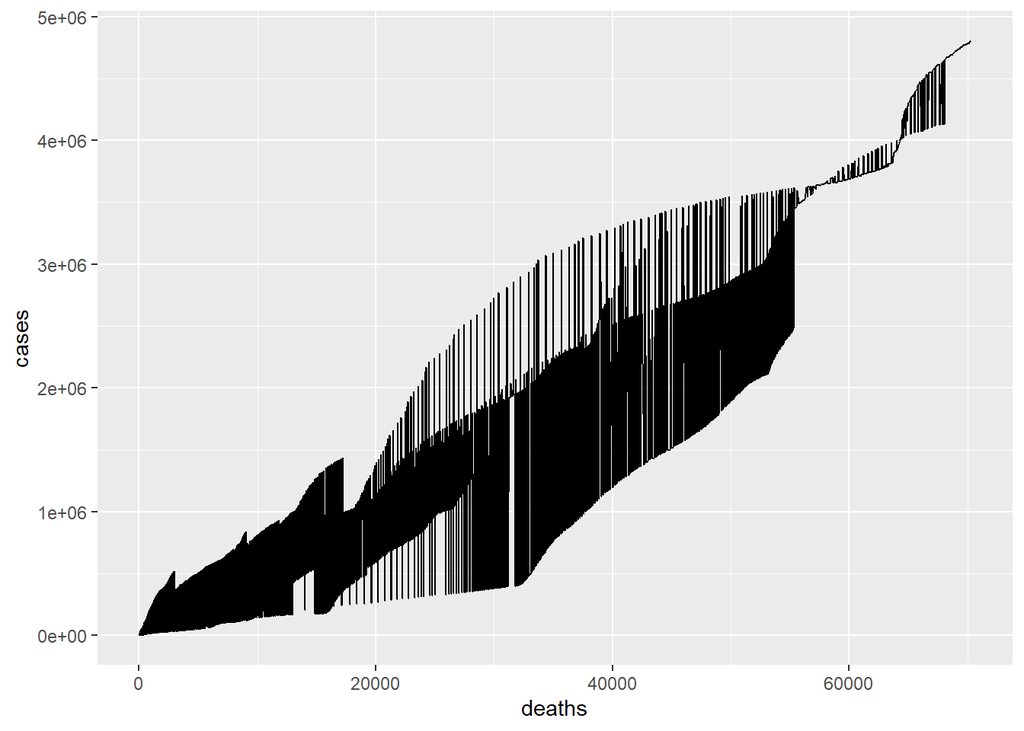

```r
df %>% ggplot()+
  geom_line(mapping = aes(x = deaths, y = cases))
```

- Smooth Plot

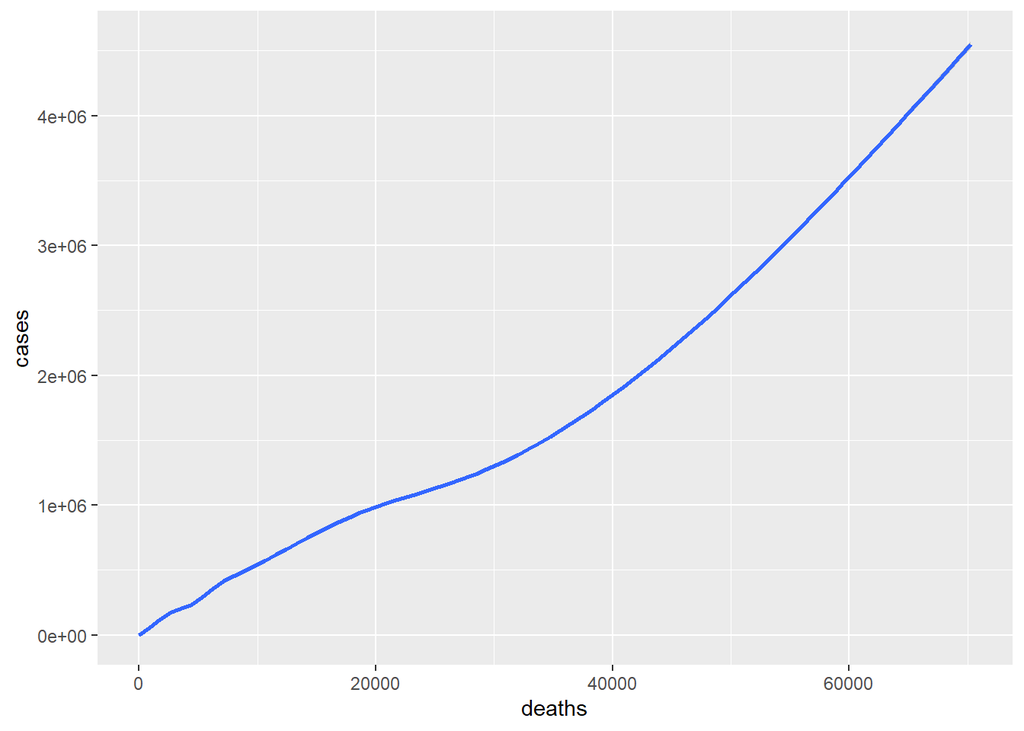

```r
df %>% ggplot()+
  geom_smooth(mapping = aes(x = deaths, y = cases))
```

4. For one continuous + one categorical variables

- Density

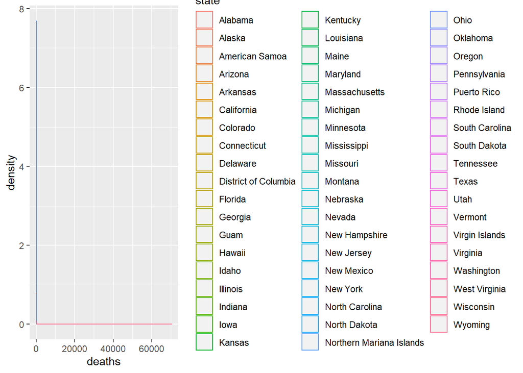

- BoxPlot

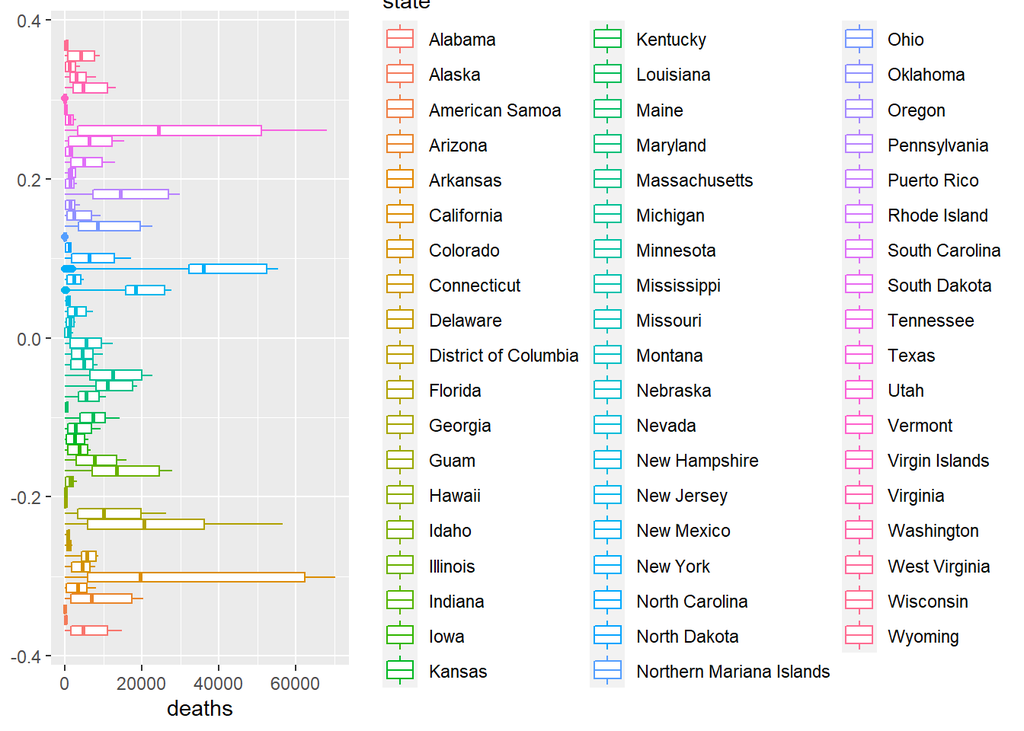

5. For two categorical variables: barplot

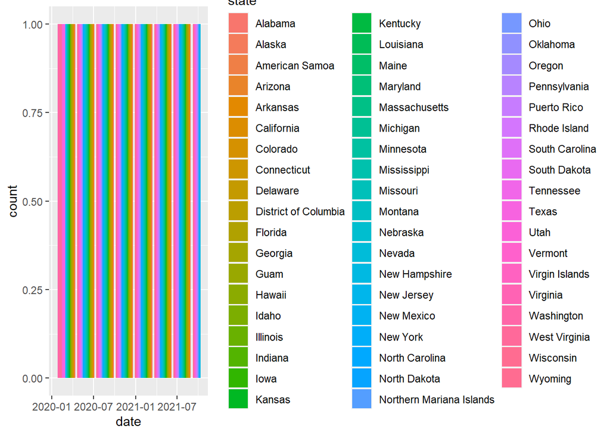

```r
df %>% ggplot()+
    geom_bar(mapping=aes(x=date, fill=state), position='dodge')
```

### Questions on Covid Vaccination Data

In this section of questions, we will use the covid vaccination data for the US. The data and data dictionary can be found at the below link:

- [Data](https://raw.githubusercontent.com/govex/COVID-19/master/data_tables/vaccine_data/us_data/time_series/vaccine_data_us_timeline.csv)
- [Data Dictionary](https://github.com/govex/COVID-19/blob/master/data_tables/vaccine_data/us_data/data_dictionary.csv)

```r
library(tidyverse)
df1 <- read_csv('https://raw.githubusercontent.com/govex/COVID-19/master/data_tables/vaccine_data/us_data/time_series/vaccine_data_us_timeline.csv')
```

Do the follows.

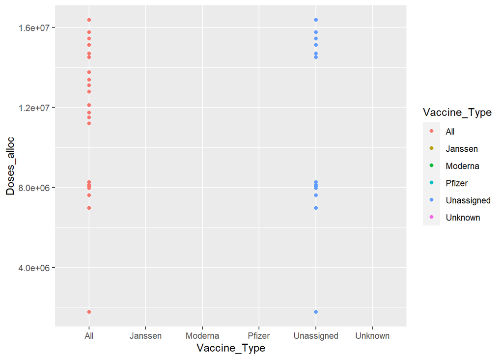

```r
df1 %>% filter(Province_State=='California') %>% ggplot()+
  geom_point(mapping = aes(x = Vaccine_Type, y = Doses_alloc, color = Vaccine_Type))
```

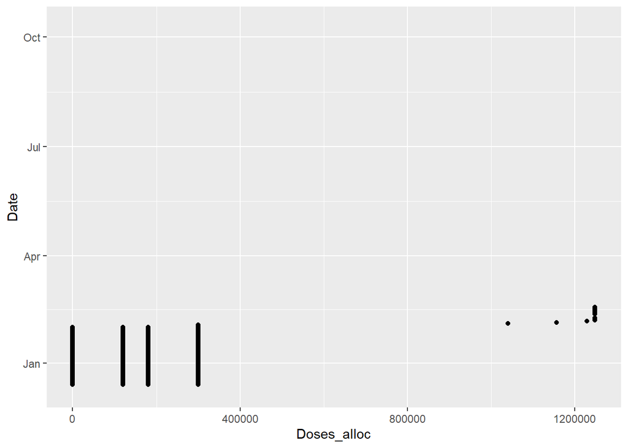

```r
df1 %>% filter(Province_State=='Massachusetts') %>% ggplot()+
    geom_point(mapping = aes(x = Doses_alloc, y = Date))
```

- Change `geom_point` to `geom_line` in the above codes to have the corresponding line plots.

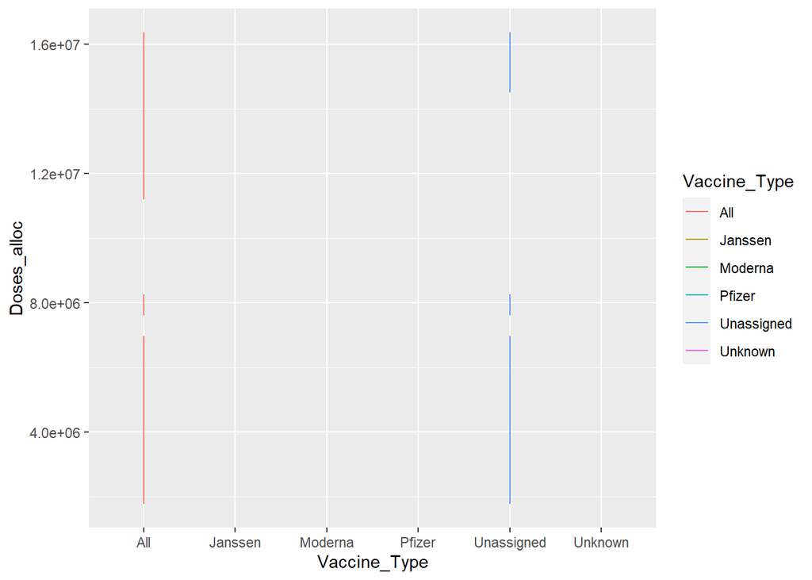

```r
df1 %>% filter(Province_State=='California') %>% ggplot()+
  geom_line(mapping = aes(x = Vaccine_Type, y = Doses_alloc, color = Vaccine_Type))
```

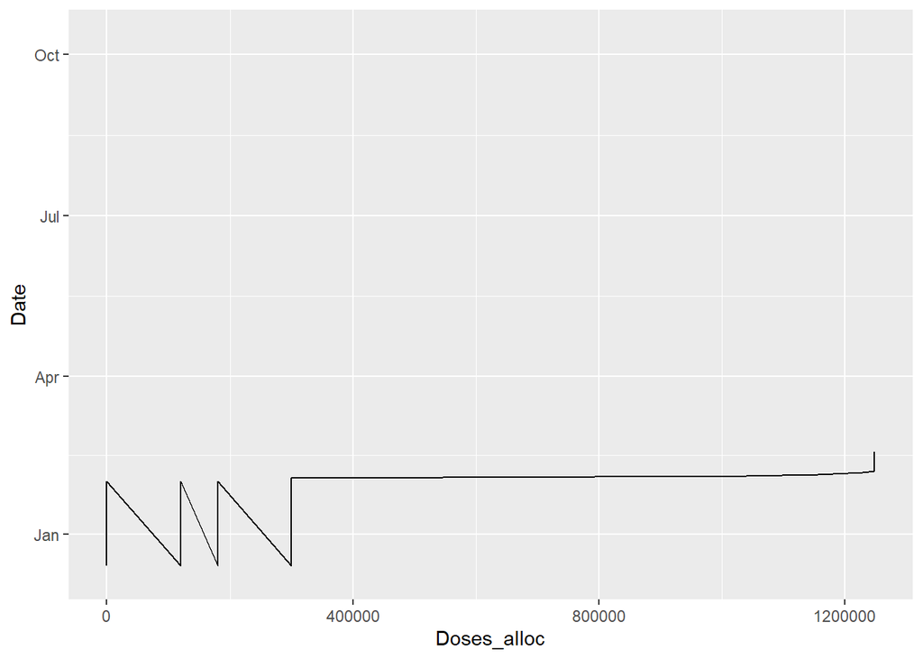

```r
df1 %>% filter(Province_State=='Massachusetts') %>% ggplot()+
    geom_line(mapping = aes(x = Doses_alloc, y = Date))
```

2. Sometime we need to do some calculations on the data before plotting. For example, to compare the popularity of two vaccine `Moderna` and `Pfizer` by date, we can use.

# Create a dataset recording these two vaccine administered by date

```r
d1 <- df1 %>% filter(Vaccine_Type==c('Moderna','Pfizer')) %>% group_by(Date, Vaccine_Type) %>% summarise(vac_admin=mean(Doses_admin, na.rm=TRUE))
```

# Plot from the newly create data

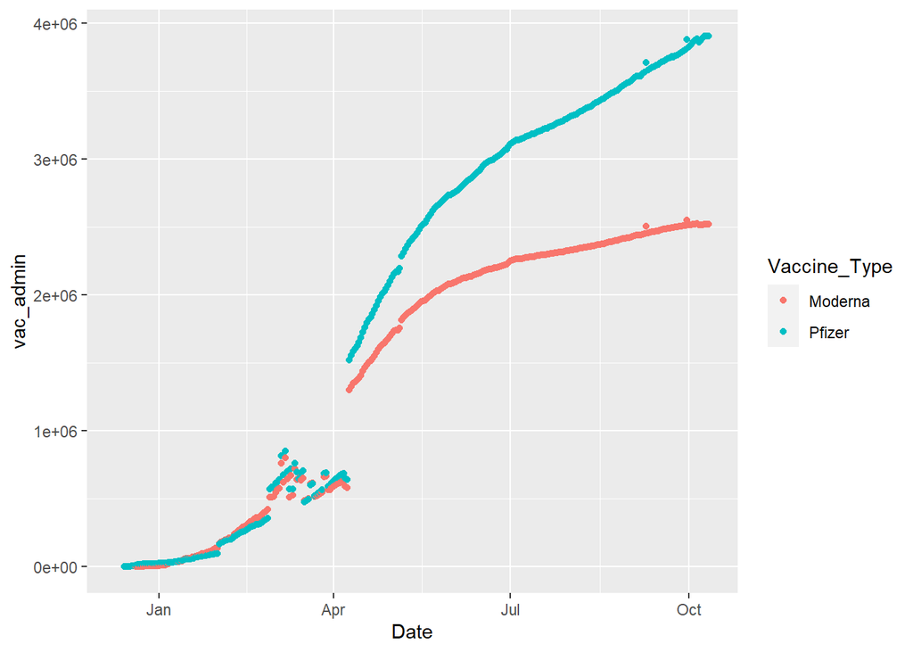

```r
d1 %>% ggplot()+geom_point(mapping=aes(x=Date, y=vac_admin, color=Vaccine_Type))
```

Do the follows.

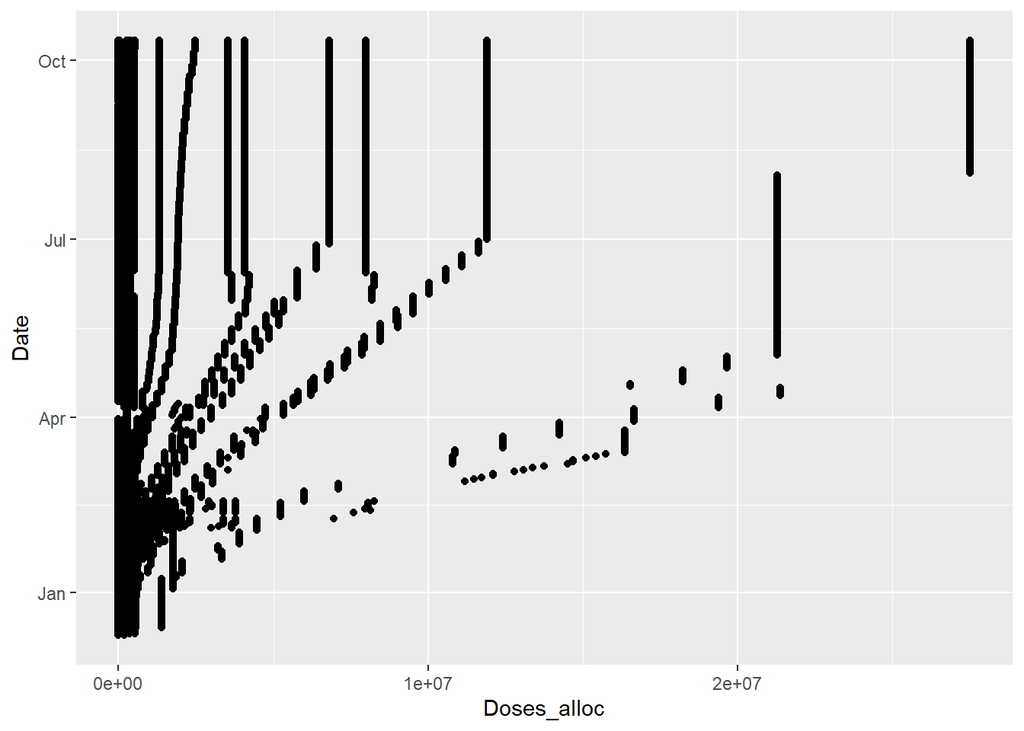

```r
df1 %>% ggplot()+
  geom_point(mapping = aes(x = Doses_alloc, y = Date))
```

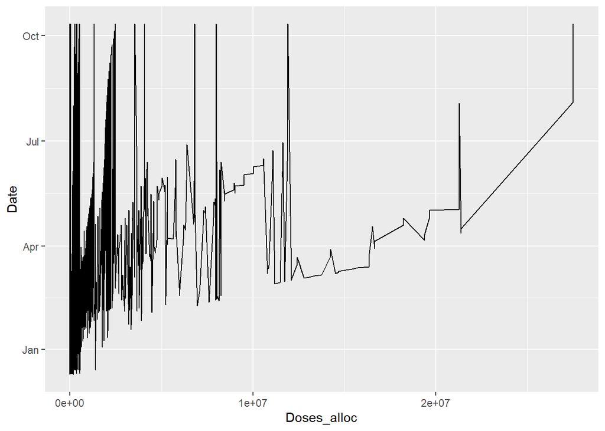

```r
df1 %>% ggplot()+
  geom_line(mapping = aes(x = Doses_alloc, y = Date))
```

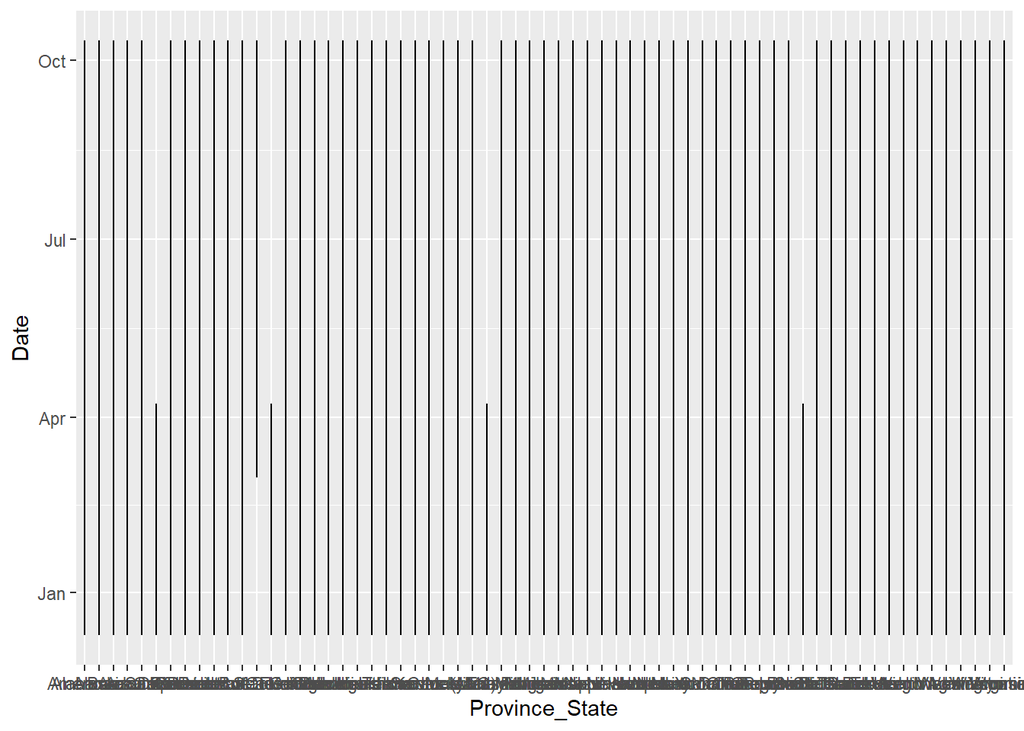

```r
df1 %>% ggplot()+
  geom_line(mapping = aes(x = Province_State, y = Date))
```

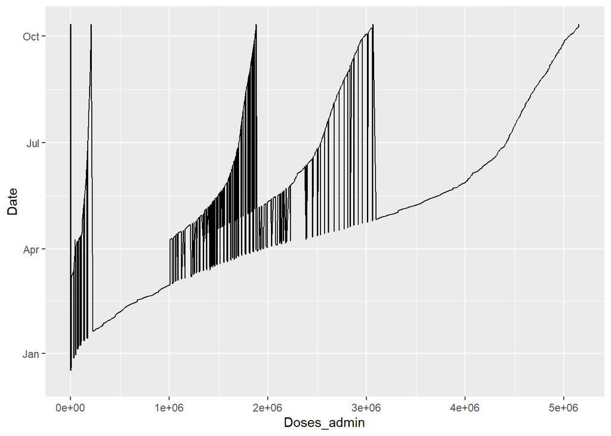

```r
df1 %>% filter(Province_State=='Connecticut') %>%  ggplot()+
  geom_line(mapping = aes(x = Doses_admin, y = Date))
```